# ADVANCED: Randomization

GVPT399F: Power, Politics, and Data

## Randomization

- Last session, we randomly assigned 1,000 hypothetical people to two different groups
- Testing whether randomization helps us create two roughly identical groups prior to treatment
- You now have a lot of the R code needed to replicate that analysis

## Creating our group of 1,000 people

Imagine we have a group of 1,000 individuals. We know the following about them:

- Height
- Weight
- Eye colour

## Creating our group of 1,000 people

```r
group_df <- tibble(
  id = 1:1000,
  height = rnorm(1000, 170, 6),
  weight = rnorm(1000, 80, 10),
  eye_colour = sample(c("Blue", "Green", "Brown", "Grey"),
                      1000,
                      replace = T)
)

group_df
```

```
# A tibble: 1,000 × 4
      id height weight eye_colour
   <int>  <dbl>  <dbl> <chr>
 1     1   169.   67.9 Blue
 2     2   158.   81.1 Grey
 3     3   167.   88.7 Grey
 4     4   161.   81.3 Blue
 5     5   172.   75.8 Blue
 6     6   169.   80.7 Blue
 7     7   169.   88.8 Brown
 8     8   169.   73.1 Grey
 9     9   171.   86.9 Green
10    10   162.   97.4 Green
# ℹ 990 more rows
```

## The Normal distribution

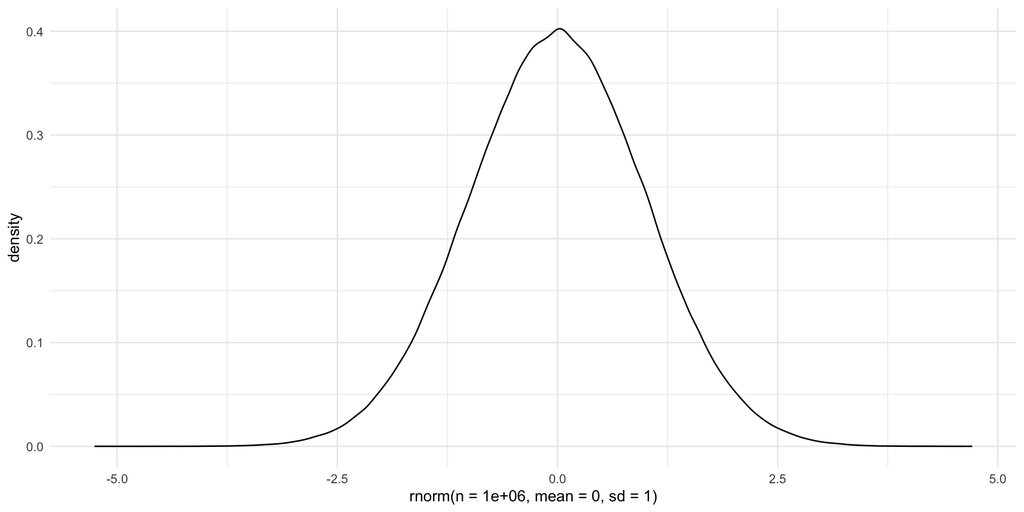

```r
ggplot() +
  geom_density(aes(x = rnorm(n = 1e6, mean = 0, sd = 1))) +
  theme_minimal()
```

## Random sampling from the Normal distribution

I can take a random sample of `n` values from a Normal distribution centered at some mean with a specific standard deviation.

- By default, `rnorm()` takes a mean of `0` and a standard deviation of `1`
- The following code takes 1,000 random samples from that default Normal distribution

If this is all nonsense to you, don’t worry! I will step through this in a lot more detail later in the course.

## Random sampling from the Normal distribution

```r
rnorm(n = 1000, mean = 0, sd = 1)
```

[output not shown]

[output cut: 185 more lines]

## Random assignment using the Binomial Distribution

Remember, we then randomly assigned them to one of two groups: A or B.

- I used random draws from the Binomial (read: binary or two) distribution to do this.

Again, do not worry if this does not make sense! Abandon this ship and go and do something more pleasant with your afternoon! We will come back to this later.

## Random assignment using the Binomial Distribution

```r
rbinom(n = 1000, size = 1, prob = 0.5)
```

[output not shown]

## The Binomial Distribution

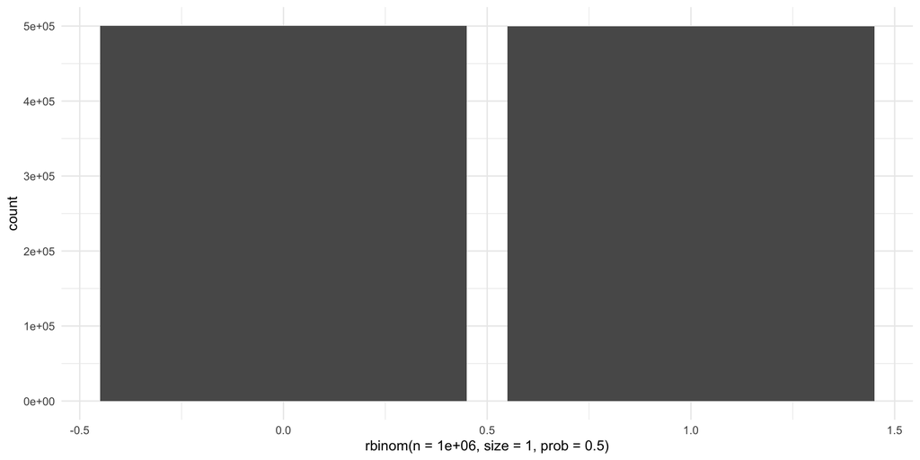

```r
ggplot() +
  geom_bar(aes(x = rbinom(n = 1e6, size = 1, prob = 0.5))) +
  theme_minimal()
```

## Assigning our people with `mutate()`

```r
assigned_group <- group_df |>
  mutate(
    group = rbinom(1000, 1, 0.5),
    group = factor(group, labels = c("A", "B"))
  )

assigned_group
```

```
# A tibble: 1,000 × 5
      id height weight eye_colour group
   <int>  <dbl>  <dbl> <chr>      <fct>
 1     1   169.   67.9 Blue       A
 2     2   158.   81.1 Grey       A
 3     3   167.   88.7 Grey       B
 4     4   161.   81.3 Blue       A
 5     5   172.   75.8 Blue       A
 6     6   169.   80.7 Blue       B
 7     7   169.   88.8 Brown      A
 8     8   169.   73.1 Grey       A
 9     9   171.   86.9 Green      A
10    10   162.   97.4 Green      B
# ℹ 990 more rows
```

## Comparing our two groups

[figure not shown]

## Comparing our two groups

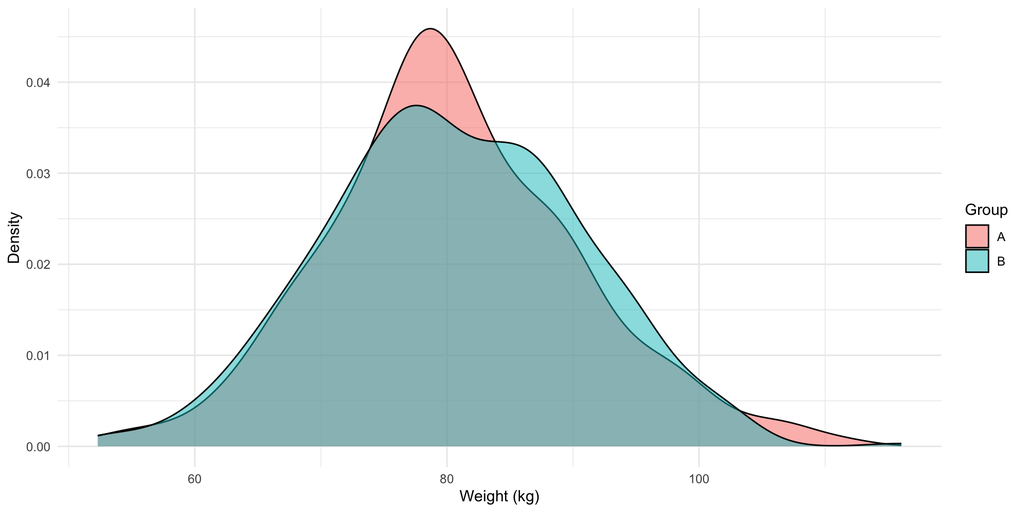

## Comparing our two groups

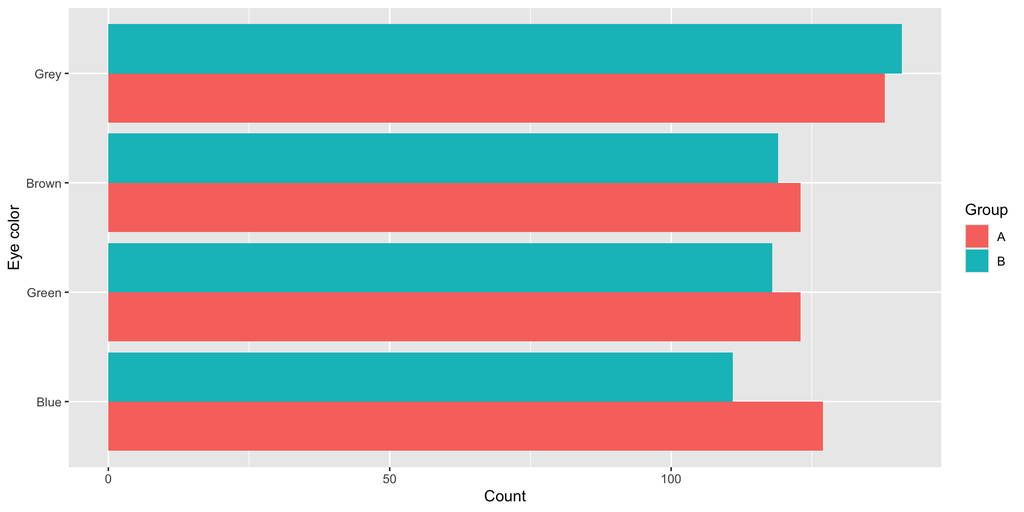